# Template — 3. Análisis Exploratorio de Datos (EDA)

**Instrucciones generales:** Usa este notebook para realizar el EDA del **dataset que seleccionaste** en la actividad *Selección de la situación problema*. En cada apartado encontrarás una celda de **instrucciones** y, a continuación, una celda de **código** para tu implementación.

```python
# Configuración general
DATA_PATH = 'train.csv'
```

## 1. Importación de librerías

Cargamos las librerías necesarias. Usaremos **pandas** para manipulación de datos y **matplotlib** para visualización.

```python
import pandas as pd
import numpy as np
import matplotlib.pyplot as plt
import seaborn as sns
from scipy.stats import f_oneway
import itertools
```

## 2. Carga e inspección inicial de los datos

- Importa las librerías básicas: **pandas**, **numpy**, **matplotlib**, **seaborn**.
- Carga el dataset (`pd.read_csv()`, `pd.read_excel()`, etc.).
- Revisa:
  - `df.shape` → tamaño del dataset (filas, columnas)
  - `df.info()` → tipos de datos y valores nulos
  - `df.head()` / `df.sample()` → primeras filas para una vista general
  - `df.describe()` → estadísticas descriptivas (promedio, desviación, min, max, cuartiles)

```python
df = pd.read_csv(DATA_PATH)
print("Shape: ", df.shape)
print("Info: ", df.info())
df.head()
df.describe(include='all')
```

```
Shape:  (8693, 14)
<class 'pandas.core.frame.DataFrame'>
RangeIndex: 8693 entries, 0 to 8692
Data columns (total 14 columns):
 #   Column        Non-Null Count  Dtype
---  ------        --------------  -----
 0   PassengerId   8693 non-null   object
 1   HomePlanet    8492 non-null   object
 2   CryoSleep     8476 non-null   object
 3   Cabin         8494 non-null   object
 4   Destination   8511 non-null   object
 5   Age           8514 non-null   float64
 6   VIP           8490 non-null   object
 7   RoomService   8512 non-null   float64
 8   FoodCourt     8510 non-null   float64
 9   ShoppingMall  8485 non-null   float64
 10  Spa           8510 non-null   float64
 11  VRDeck        8505 non-null   float64
 12  Name          8493 non-null   object
 13  Transported   8693 non-null   bool
dtypes: bool(1), float64(6), object(7)
memory usage: 891.5+ KB
Info:  None
```

|  | PassengerId | HomePlanet | CryoSleep | Cabin | Destination | Age | VIP | RoomService | FoodCourt | ShoppingMall | Spa | VRDeck | Name | Transported |
| --- | --- | --- | --- | --- | --- | --- | --- | --- | --- | --- | --- | --- | --- | --- |
| count | 8693 | 8492 | 8476 | 8494 | 8511 | 8514.000000 | 8490 | 8512.000000 | 8510.000000 | 8485.000000 | 8510.000000 | 8505.000000 | 8493 | 8693 |
| unique | 8693 | 3 | 2 | 6560 | 3 | NaN | 2 | NaN | NaN | NaN | NaN | NaN | 8473 | 2 |
| top | 0001_01 | Earth | False | G/734/S | TRAPPIST-1e | NaN | False | NaN | NaN | NaN | NaN | NaN | Gollux Reedall | True |
| freq | 1 | 4602 | 5439 | 8 | 5915 | NaN | 8291 | NaN | NaN | NaN | NaN | NaN | 2 | 4378 |
| mean | NaN | NaN | NaN | NaN | NaN | 28.827930 | NaN | 224.687617 | 458.077203 | 173.729169 | 311.138778 | 304.854791 | NaN | NaN |
| std | NaN | NaN | NaN | NaN | NaN | 14.489021 | NaN | 666.717663 | 1611.489240 | 604.696458 | 1136.705535 | 1145.717189 | NaN | NaN |
| min | NaN | NaN | NaN | NaN | NaN | 0.000000 | NaN | 0.000000 | 0.000000 | 0.000000 | 0.000000 | 0.000000 | NaN | NaN |
| 25% | NaN | NaN | NaN | NaN | NaN | 19.000000 | NaN | 0.000000 | 0.000000 | 0.000000 | 0.000000 | 0.000000 | NaN | NaN |
| 50% | NaN | NaN | NaN | NaN | NaN | 27.000000 | NaN | 0.000000 | 0.000000 | 0.000000 | 0.000000 | 0.000000 | NaN | NaN |
| 75% | NaN | NaN | NaN | NaN | NaN | 38.000000 | NaN | 47.000000 | 76.000000 | 27.000000 | 59.000000 | 46.000000 | NaN | NaN |
| max | NaN | NaN | NaN | NaN | NaN | 79.000000 | NaN | 14327.000000 | 29813.000000 | 23492.000000 | 22408.000000 | 24133.000000 | NaN | NaN |

## 3. Identificación de tipos de variables

Clasifica las columnas:

- **Numéricas continuas**: edad, salario, temperatura
- **Numéricas discretas**: número de hijos, cantidad de productos
- **Categóricas**: género, país, color
- **Ordinales**: nivel de educación, satisfacción (bajo, medio, alto)
- **Fechas o temporales**: fecha de compra, hora del evento

```python
# Variables numéricas continuas
v_num_cont = ['Age', 'RoomService', 'FoodCourt', 'ShoppingMall', 'Spa', 'VRDeck']
# Variables numéricas discretas
v_num_disc = ['']
# Variables categóricas
v_cat = ['PassengerId', 'HomePlanet', 'CryoSleep', 'Cabin', 'Destination', 'VIP', 'Name', 'Transported']
# Variables ordinales
v_ord = ['']
#  Variables fechas o temporales
v_temp = ['']

# No tenemos variables discretas, ordinales o temporales,
# Existen variables numéricas continuas que corresponden a lo que se gastó en cada servicio y la edad
# Las variables categóricas corresponden a las diferentes características que tenía el viaje e identificadores del pasajero
```

## 4. Limpieza de datos

**Valores faltantes:**

- Identificar (`df.isnull().sum()`)
- Decidir si se imputan (media, mediana, moda, interpolación) o se eliminan.

**Duplicados:**

- Detectar (`df.duplicated()`) y eliminar (`df.drop_duplicates()`).

**Outliers (valores atípicos):**

- Detectar mediante **boxplots**, **z-score** o **rango intercuartílico (IQR)**.
- Analizar si son errores o casos reales.
- Borrar algunos *outliers* si es necesario.

**Tipos de datos incorrectos:**

- Convertir *strings* a fechas (`pd.to_datetime()`), numéricos, etc.

```python
# Limpiar datos
# Valores faltantes
v_num_cont = ['Age', 'RoomService', 'FoodCourt', 'ShoppingMall', 'Spa', 'VRDeck']

df.isnull().sum()

# Llenar los valores faltantes, las variables categóricas se llenan con la moda mientras que las numéricas con la mediana
df['Age'] = df['Age'].fillna(df['Age'].median())
df['RoomService'] = df['RoomService'].fillna(df['RoomService'].median())
df['FoodCourt'] = df['FoodCourt'].fillna(df['FoodCourt'].median())
df['ShoppingMall'] = df['ShoppingMall'].fillna(df['ShoppingMall'].median())
df['Spa'] = df['Spa'].fillna(df['Spa'].median())
df['VRDeck'] = df['VRDeck'].fillna(df['VRDeck'].median())
df['HomePlanet'] = df['HomePlanet'].fillna(df['HomePlanet'].mode()[0])
df['CryoSleep'] = df['CryoSleep'].fillna(df['CryoSleep'].mode()[0])
df['Cabin'] = df['Cabin'].fillna(df['Cabin'].mode()[0])
df['Destination'] = df['Destination'].fillna(df['Destination'].mode()[0])
df['VIP'] = df['VIP'].fillna(df['VIP'].mode()[0])
df['Name'] = df['Name'].fillna("None")
#df = df.drop(columns=['Name'])

# Duplicados
df.duplicated()
df.drop_duplicates()
```

|  | PassengerId | HomePlanet | CryoSleep | Cabin | Destination | Age | VIP | RoomService | FoodCourt | ShoppingMall | Spa | VRDeck | Name | Transported |
| --- | --- | --- | --- | --- | --- | --- | --- | --- | --- | --- | --- | --- | --- | --- |
| 0 | 0001_01 | Europa | False | B/0/P | TRAPPIST-1e | 39.0 | False | 0.0 | 0.0 | 0.0 | 0.0 | 0.0 | Maham Ofracculy | False |
| 1 | 0002_01 | Earth | False | F/0/S | TRAPPIST-1e | 24.0 | False | 109.0 | 9.0 | 25.0 | 549.0 | 44.0 | Juanna Vines | True |
| 2 | 0003_01 | Europa | False | A/0/S | TRAPPIST-1e | 58.0 | True | 43.0 | 3576.0 | 0.0 | 6715.0 | 49.0 | Altark Susent | False |
| 3 | 0003_02 | Europa | False | A/0/S | TRAPPIST-1e | 33.0 | False | 0.0 | 1283.0 | 371.0 | 3329.0 | 193.0 | Solam Susent | False |
| 4 | 0004_01 | Earth | False | F/1/S | TRAPPIST-1e | 16.0 | False | 303.0 | 70.0 | 151.0 | 565.0 | 2.0 | Willy Santantines | True |
| ... | ... | ... | ... | ... | ... | ... | ... | ... | ... | ... | ... | ... | ... | ... |
| 8688 | 9276_01 | Europa | False | A/98/P | 55 Cancri e | 41.0 | True | 0.0 | 6819.0 | 0.0 | 1643.0 | 74.0 | Gravior Noxnuther | False |
| 8689 | 9278_01 | Earth | True | G/1499/S | PSO J318.5-22 | 18.0 | False | 0.0 | 0.0 | 0.0 | 0.0 | 0.0 | Kurta Mondalley | False |
| 8690 | 9279_01 | Earth | False | G/1500/S | TRAPPIST-1e | 26.0 | False | 0.0 | 0.0 | 1872.0 | 1.0 | 0.0 | Fayey Connon | True |
| 8691 | 9280_01 | Europa | False | E/608/S | 55 Cancri e | 32.0 | False | 0.0 | 1049.0 | 0.0 | 353.0 | 3235.0 | Celeon Hontichre | False |
| 8692 | 9280_02 | Europa | False | E/608/S | TRAPPIST-1e | 44.0 | False | 126.0 | 4688.0 | 0.0 | 0.0 | 12.0 | Propsh Hontichre | True |

8693 rows × 14 columns

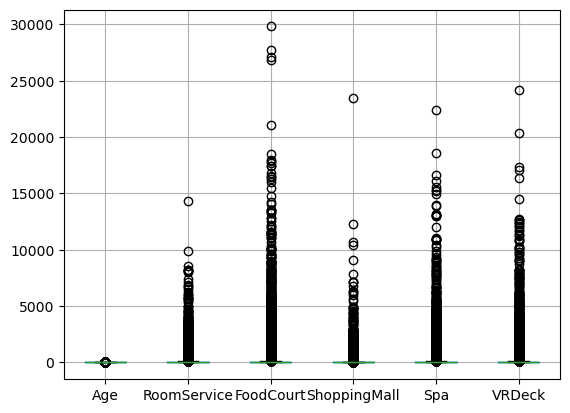

```python
# Outliers

# Se hace un boxplot para las variables numéricas

df.boxplot(column=v_num_cont)
```

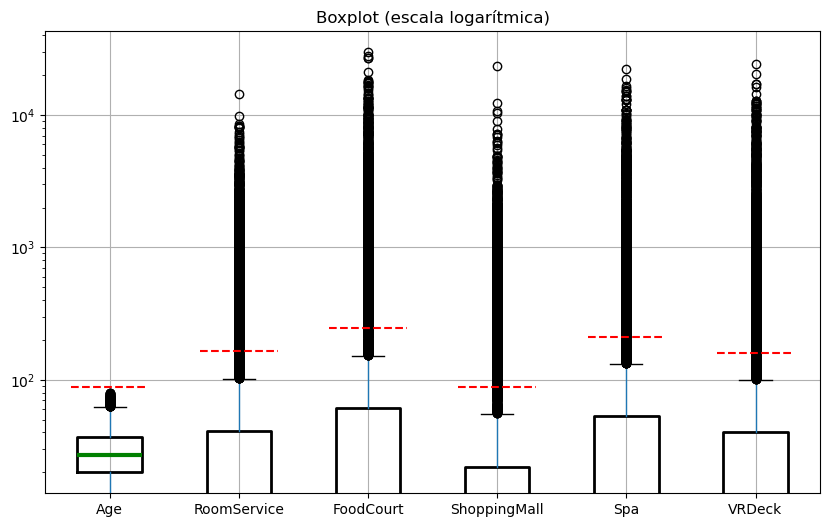

```python
# Luego se hace el análisis con IQR

Q1 = df[v_num_cont].quantile(0.25)
Q3 = df[v_num_cont].quantile(0.75)
IQR = Q3 - Q1
IQR

# Graficamos el análisis de IQR

LS = Q3 + 3 * IQR
LI = Q1 - 3 * IQR

ax = df.boxplot(
    column=v_num_cont,
    figsize=(10, 6),
    medianprops=dict(linewidth=3, color='green'),
    boxprops=dict(linewidth=2)
)


for i, col in enumerate(v_num_cont, start=1):
    ax.hlines(LS[col], i-0.3, i+0.3, colors='red', linestyles='dashed')
    ax.hlines(LI[col], i-0.3, i+0.3, colors='red', linestyles='dashed')


ax.set_yscale('log')
plt.title('Boxplot (escala logarítmica)')
plt.show()
```

```python
# Se analizan los outliers
for col in v_num_cont:
    outliers = df[(df[col] > LS[col]) | (df[col] < LI[col])]
    print(f"\n{col}: {len(outliers)} outliers ({len(outliers)/len(df)*100:.2f}%)")
    display(outliers[[col]].describe())
    display(outliers.head())


print("Edades")
# Vemos si existen edades negativas
print(df[df['Age'] < 0])
#  Si hay edades muy altas
print(df[df['Age'] > 100])
print("Gastos")
# Vemos si hay gastos negativos
print(df[df['FoodCourt'] < 0])
print(df[df['RoomService'] < 0])
print(df[df['ShoppingMall'] < 0])
print(df[df['Spa'] < 0])
print(df[df['VRDeck'] < 0])

# No borramos outliers puesto que los datos parecen estar correctos y existe mucha diversidad en los rangos que se presentan.
```

```
Age: 0 outliers (0.00%)
```

|  | Age |
| --- | --- |
| count | 0.0 |
| mean | NaN |
| std | NaN |
| min | NaN |
| 25% | NaN |
| 50% | NaN |
| 75% | NaN |
| max | NaN |

|  | PassengerId | HomePlanet | CryoSleep | Cabin | Destination | Age | VIP | RoomService | FoodCourt | ShoppingMall | Spa | VRDeck | Name | Transported |
| --- | --- | --- | --- | --- | --- | --- | --- | --- | --- | --- | --- | --- | --- | --- |

```
RoomService: 1728 outliers (19.88%)
```

|  | RoomService |
| --- | --- |
| count | 1728.000000 |
| mean | 1077.418981 |
| std | 1129.272063 |
| min | 165.000000 |
| 25% | 435.000000 |
| 50% | 748.000000 |
| 75% | 1264.000000 |
| max | 14327.000000 |

|  | PassengerId | HomePlanet | CryoSleep | Cabin | Destination | Age | VIP | RoomService | FoodCourt | ShoppingMall | Spa | VRDeck | Name | Transported |
| --- | --- | --- | --- | --- | --- | --- | --- | --- | --- | --- | --- | --- | --- | --- |
| 4 | 0004_01 | Earth | False | F/1/S | TRAPPIST-1e | 16.0 | False | 303.0 | 70.0 | 151.0 | 565.0 | 2.0 | Willy Santantines | True |
| 13 | 0010_01 | Earth | False | G/1/S | TRAPPIST-1e | 48.0 | False | 719.0 | 1.0 | 65.0 | 0.0 | 24.0 | Reney Baketton | False |
| 16 | 0014_01 | Mars | False | F/3/P | 55 Cancri e | 27.0 | False | 1286.0 | 122.0 | 0.0 | 0.0 | 0.0 | Flats Eccle | False |
| 20 | 0017_02 | Earth | False | F/6/P | 55 Cancri e | 14.0 | False | 412.0 | 0.0 | 1.0 | 0.0 | 679.0 | Philda Brighttt | False |
| 27 | 0022_01 | Mars | False | D/0/P | TRAPPIST-1e | 21.0 | False | 980.0 | 2.0 | 69.0 | 0.0 | 0.0 | None | False |

```
FoodCourt: 1719 outliers (19.77%)
```

|  | FoodCourt |
| --- | --- |
| count | 1719.000000 |
| mean | 2221.646306 |
| std | 2992.735358 |
| min | 245.000000 |
| 25% | 600.000000 |
| 50% | 1012.000000 |
| 75% | 2691.500000 |
| max | 29813.000000 |

|  | PassengerId | HomePlanet | CryoSleep | Cabin | Destination | Age | VIP | RoomService | FoodCourt | ShoppingMall | Spa | VRDeck | Name | Transported |
| --- | --- | --- | --- | --- | --- | --- | --- | --- | --- | --- | --- | --- | --- | --- |
| 2 | 0003_01 | Europa | False | A/0/S | TRAPPIST-1e | 58.0 | True | 43.0 | 3576.0 | 0.0 | 6715.0 | 49.0 | Altark Susent | False |
| 3 | 0003_02 | Europa | False | A/0/S | TRAPPIST-1e | 33.0 | False | 0.0 | 1283.0 | 371.0 | 3329.0 | 193.0 | Solam Susent | False |
| 5 | 0005_01 | Earth | False | F/0/P | PSO J318.5-22 | 44.0 | False | 0.0 | 483.0 | 0.0 | 291.0 | 0.0 | Sandie Hinetthews | True |
| 6 | 0006_01 | Earth | False | F/2/S | TRAPPIST-1e | 26.0 | False | 42.0 | 1539.0 | 3.0 | 0.0 | 0.0 | Billex Jacostaffey | True |
| 8 | 0007_01 | Earth | False | F/3/S | TRAPPIST-1e | 35.0 | False | 0.0 | 785.0 | 17.0 | 216.0 | 0.0 | Andona Beston | True |

```
ShoppingMall: 1732 outliers (19.92%)
```

|  | ShoppingMall |
| --- | --- |
| count | 1732.000000 |
| mean | 835.625289 |
| std | 1113.865542 |
| min | 89.000000 |
| 25% | 288.750000 |
| 50% | 612.000000 |
| 75% | 918.750000 |
| max | 23492.000000 |

|  | PassengerId | HomePlanet | CryoSleep | Cabin | Destination | Age | VIP | RoomService | FoodCourt | ShoppingMall | Spa | VRDeck | Name | Transported |
| --- | --- | --- | --- | --- | --- | --- | --- | --- | --- | --- | --- | --- | --- | --- |
| 3 | 0003_02 | Europa | False | A/0/S | TRAPPIST-1e | 33.0 | False | 0.0 | 1283.0 | 371.0 | 3329.0 | 193.0 | Solam Susent | False |
| 4 | 0004_01 | Earth | False | F/1/S | TRAPPIST-1e | 16.0 | False | 303.0 | 70.0 | 151.0 | 565.0 | 2.0 | Willy Santantines | True |
| 11 | 0008_03 | Europa | False | B/1/P | 55 Cancri e | 45.0 | False | 39.0 | 7295.0 | 589.0 | 110.0 | 124.0 | Wezena Flatic | True |
| 12 | 0009_01 | Mars | False | F/1/P | TRAPPIST-1e | 32.0 | False | 73.0 | 0.0 | 1123.0 | 0.0 | 113.0 | Berers Barne | True |
| 15 | 0012_01 | Earth | False | G/734/S | TRAPPIST-1e | 31.0 | False | 32.0 | 0.0 | 876.0 | 0.0 | 0.0 | Justie Pooles | False |

```
Spa: 1617 outliers (18.60%)
```

|  | Spa |
| --- | --- |
| count | 1617.000000 |
| mean | 1586.800247 |
| std | 2188.102995 |
| min | 213.000000 |
| 25% | 481.000000 |
| 50% | 760.000000 |
| 75% | 1695.000000 |
| max | 22408.000000 |

|  | PassengerId | HomePlanet | CryoSleep | Cabin | Destination | Age | VIP | RoomService | FoodCourt | ShoppingMall | Spa | VRDeck | Name | Transported |
| --- | --- | --- | --- | --- | --- | --- | --- | --- | --- | --- | --- | --- | --- | --- |
| 1 | 0002_01 | Earth | False | F/0/S | TRAPPIST-1e | 24.0 | False | 109.0 | 9.0 | 25.0 | 549.0 | 44.0 | Juanna Vines | True |
| 2 | 0003_01 | Europa | False | A/0/S | TRAPPIST-1e | 58.0 | True | 43.0 | 3576.0 | 0.0 | 6715.0 | 49.0 | Altark Susent | False |
| 3 | 0003_02 | Europa | False | A/0/S | TRAPPIST-1e | 33.0 | False | 0.0 | 1283.0 | 371.0 | 3329.0 | 193.0 | Solam Susent | False |
| 4 | 0004_01 | Earth | False | F/1/S | TRAPPIST-1e | 16.0 | False | 303.0 | 70.0 | 151.0 | 565.0 | 2.0 | Willy Santantines | True |
| 5 | 0005_01 | Earth | False | F/0/P | PSO J318.5-22 | 44.0 | False | 0.0 | 483.0 | 0.0 | 291.0 | 0.0 | Sandie Hinetthews | True |

```
VRDeck: 1692 outliers (19.46%)
```

|  | VRDeck |
| --- | --- |
| count | 1692.000000 |
| mean | 1502.072695 |
| std | 2192.865304 |
| min | 161.000000 |
| 25% | 418.750000 |
| 50% | 738.500000 |
| 75% | 1541.500000 |
| max | 24133.000000 |

|  | PassengerId | HomePlanet | CryoSleep | Cabin | Destination | Age | VIP | RoomService | FoodCourt | ShoppingMall | Spa | VRDeck | Name | Transported |
| --- | --- | --- | --- | --- | --- | --- | --- | --- | --- | --- | --- | --- | --- | --- |
| 3 | 0003_02 | Europa | False | A/0/S | TRAPPIST-1e | 33.0 | False | 0.0 | 1283.0 | 371.0 | 3329.0 | 193.0 | Solam Susent | False |
| 17 | 0015_01 | Earth | False | F/4/P | 55 Cancri e | 24.0 | False | 0.0 | 1.0 | 0.0 | 0.0 | 637.0 | Carry Hughriend | False |
| 20 | 0017_02 | Earth | False | F/6/P | 55 Cancri e | 14.0 | False | 412.0 | 0.0 | 1.0 | 0.0 | 679.0 | Philda Brighttt | False |
| 30 | 0026_01 | Europa | False | C/0/P | 55 Cancri e | 34.0 | False | 22.0 | 6073.0 | 0.0 | 1438.0 | 328.0 | Anyoni Unconary | False |
| 32 | 0030_01 | Earth | False | G/4/S | TRAPPIST-1e | 32.0 | False | 0.0 | 850.0 | 81.0 | 437.0 | 453.0 | Ginia Morsentley | False |

```
Edades
Empty DataFrame
Columns: [PassengerId, HomePlanet, CryoSleep, Cabin, Destination, Age, VIP, RoomService, FoodCourt, ShoppingMall, Spa, VRDeck, Name, Transported]
Index: []
Empty DataFrame
Columns: [PassengerId, HomePlanet, CryoSleep, Cabin, Destination, Age, VIP, RoomService, FoodCourt, ShoppingMall, Spa, VRDeck, Name, Transported]
Index: []
Gastos
Empty DataFrame
Columns: [PassengerId, HomePlanet, CryoSleep, Cabin, Destination, Age, VIP, RoomService, FoodCourt, ShoppingMall, Spa, VRDeck, Name, Transported]
Index: []
Empty DataFrame
Columns: [PassengerId, HomePlanet, CryoSleep, Cabin, Destination, Age, VIP, RoomService, FoodCourt, ShoppingMall, Spa, VRDeck, Name, Transported]
Index: []
Empty DataFrame
Columns: [PassengerId, HomePlanet, CryoSleep, Cabin, Destination, Age, VIP, RoomService, FoodCourt, ShoppingMall, Spa, VRDeck, Name, Transported]
Index: []
Empty DataFrame
Columns: [PassengerId, HomePlanet, CryoSleep, Cabin, Destination, Age, VIP, RoomService, FoodCourt, ShoppingMall, Spa, VRDeck, Name, Transported]
Index: []
Empty DataFrame
Columns: [PassengerId, HomePlanet, CryoSleep, Cabin, Destination, Age, VIP, RoomService, FoodCourt, ShoppingMall, Spa, VRDeck, Name, Transported]
Index: []
```

```python
# Convertir strings a fechas

# No se hace porque no hay columna que tenga fechas como tipos
```

## 4. Análisis univariado

Analiza cada variable individualmente:

- **Numéricas**: histogramas, boxplots, medidas de tendencia y dispersión.
- **Categóricas**: conteos, porcentajes, gráficos de barras.
- **Fechas**: conteo de eventos por día, mes, año.

**Objetivo:** entender la distribución, detectar sesgos o escalas anómalas.

### Variables númericas

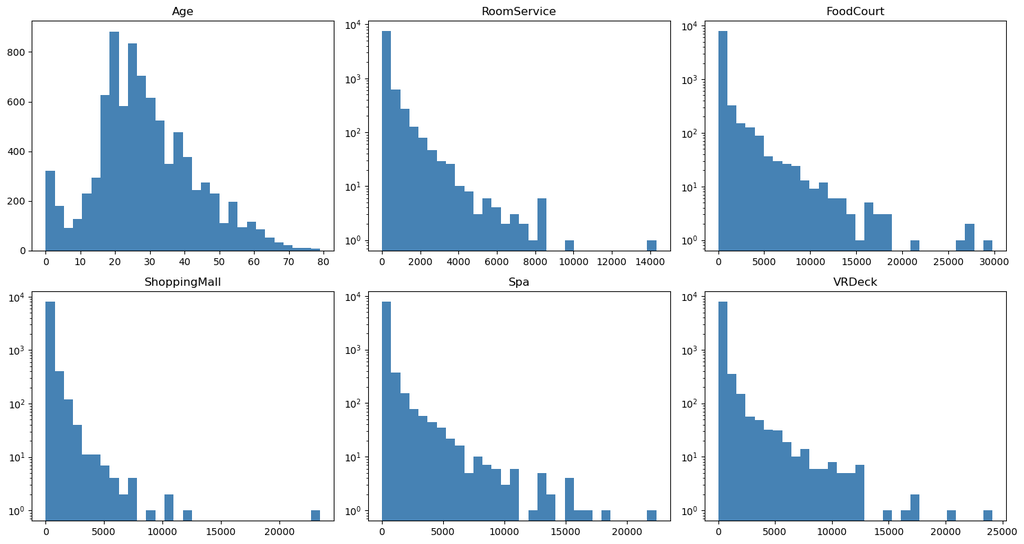

```python
# Histogramas para los datos

fig, axes = plt.subplots(2, 3, figsize=(15, 8))
axes = axes.flatten()

for i, col in enumerate(v_num_cont):
    axes[i].hist(df[col].dropna(), bins=30, color='steelblue')
    axes[i].set_title(col)
    if col != 'Age':
        axes[i].set_yscale('log')

plt.tight_layout()
plt.show()
```

```python
# Medidas de tendencia y dispersión

# Varianza
print("Varianza")
print(df[v_num_cont].var())

# Desviación estándar
print("\nDesviación estándar")
print(df[v_num_cont].std())

# Coeficiente de variación
print("\nCoeficiente de variación")
print(df[v_num_cont].std() / df[v_num_cont].mean())

# Media
print("\nMedia")
print(df[v_num_cont].mean())

# Mediana
print("\nMediana")
print(df[v_num_cont].median())

# Moda
print("\nModa")
print(df[v_num_cont].mode())

# Asimetría
print("\nAsimetría")
print(df[v_num_cont].skew())

# Curtosis
print("\nCurtosis")
print(df[v_num_cont].kurt())
```

```
Varianza
Age             2.056759e+02
RoomService     4.362854e+05
FoodCourt       2.546548e+06
ShoppingMall    3.576126e+05
Spa             1.266891e+06
VRDeck          1.286243e+06
dtype: float64

Desviación estándar
Age               14.341404
RoomService      660.519050
FoodCourt       1595.790627
ShoppingMall     598.007164
Spa             1125.562559
VRDeck          1134.126417
dtype: float64

Coeficiente de variación
Age             0.498133
RoomService     3.002232
FoodCourt       3.558585
ShoppingMall    3.526562
Spa             3.695350
VRDeck          3.802453
dtype: float64

Media
Age              28.790291
RoomService     220.009318
FoodCourt       448.434027
ShoppingMall    169.572300
Spa             304.588865
VRDeck          298.261820
dtype: float64

Mediana
Age             27.0
RoomService      0.0
FoodCourt        0.0
```

[output cut: 11 more lines]

```
RoomService      6.397766
FoodCourt        7.177515
ShoppingMall    12.763842
Spa              7.716450
VRDeck           7.904554
dtype: float64

Curtosis
Age               0.169570
RoomService      66.577452
FoodCourt        74.856189
ShoppingMall    336.017352
Spa              82.920686
VRDeck           87.883437
dtype: float64
```

### Variables categoricas

```python
# Para las variables categóricas
v_cat_analisis = [col for col in v_cat if col not in ['PassengerId', 'Name']]

# Conteos

print("Conteos")
print(df[v_cat].count())

# Porcentajes de cada variable

print("\nPorcentajes")

for col in v_cat_analisis:
  print("\n",(df[col].value_counts(normalize=True))*100)
```

```
Conteos
```

```
PassengerId    8693
HomePlanet     8693
CryoSleep      8693
Cabin          8693
Destination    8693
VIP            8693
Name           8693
Transported    8693
dtype: int64

Porcentajes

 HomePlanet
Earth     55.251352
Europa    24.513977
Mars      20.234672
Name: proportion, dtype: float64

 CryoSleep
False    65.063844
True     34.936156
Name: proportion, dtype: float64

 Cabin
G/734/S     2.381226
C/21/P      0.080525
B/201/P     0.080525
G/1368/P    0.080525
E/13/S      0.080525
              ...
G/556/P     0.011504
E/231/S     0.011504
G/545/S     0.011504
G/543/S     0.011504
F/947/P     0.011504
Name: proportion, Length: 6560, dtype: float64

 Destination
TRAPPIST-1e      70.136892
55 Cancri e      20.706315
PSO J318.5-22     9.156793
Name: proportion, dtype: float64

 VIP
False    97.710802
True      2.289198
Name: proportion, dtype: float64

 Transported
True     50.362361
False    49.637639
Name: proportion, dtype: float64
```

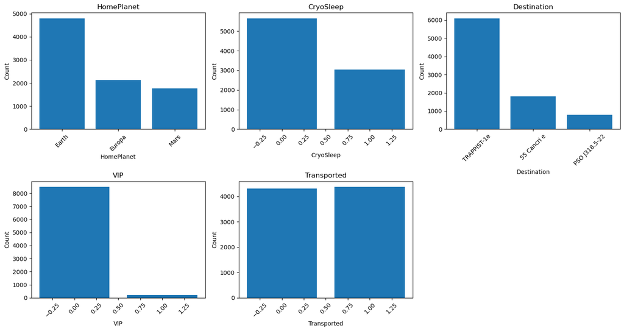

```python
# Gráfica de barras

# Excluir 'Cabin', 'PassengerId', 'Name' de la lista para gráficos de barras generales debido a su alta cardinalidad.
v_cat_analisis_filtered = [col for col in v_cat if col not in ['PassengerId', 'Name', 'Cabin']]

num_vars_to_plot = len(v_cat_analisis_filtered)
cols = 3 # Número deseado de columnas por fila
rows = (num_vars_to_plot + cols - 1) // cols # Cálculo dinámico de filas

fig, axes = plt.subplots(rows, cols, figsize=(5 * cols, 4 * rows))
axes = axes.flatten()

for i, col in enumerate(v_cat_analisis_filtered):
    axes[i].bar(df[col].value_counts().index, df[col].value_counts().values)
    axes[i].set_title(col)
    axes[i].set_xlabel(col)
    axes[i].set_ylabel('Count')
    axes[i].tick_params(axis='x', rotation=45) # Rotar etiquetas para mejor legibilidad

# Ocultar cualquier subplot no utilizado
for j in range(num_vars_to_plot, len(axes)):
    fig.delaxes(axes[j])

plt.tight_layout()
plt.show()
```

[figure not shown]

```python
plt.figure(figsize=(15, 8))
sns.countplot(data=df, x='Cabin')
plt.show()
```

Debido a que la columna "Cabin" tiene alta cardinalidad, lo que lo hace dificil representarla en un grafico de barras estándar. Mas adelante mostramos como se desglosa para poder usarla de manera eficaz.

## 5. Análisis bivariado y multivariado

Explora relaciones entre variables:

- **Numérica vs numérica**: scatter, correlación (`df.corr()`), mapa de calor.
- **Numérica vs categórica**: boxplots, *violin plots*, ANOVA.
- **Categórica vs categórica**: tablas de contingencia, barras apiladas.
- **Con la variable objetivo**: detectar patrones que expliquen el *target*.

### Scatter plot

```python
# Numérica vs numérica

pares = list(itertools.combinations(v_num_cont, 2))
n = len(pares)
cols = 3
rows = -(-n // cols)

fig, axes = plt.subplots(rows, cols, figsize=(6*cols, 5*rows))
axes = axes.flatten()

for i, (x_col, y_col) in enumerate(pares):
    sns.scatterplot(data=df, x=x_col, y=y_col, hue='Transported', alpha=0.5, ax=axes[i])
    axes[i].set_title(f'{x_col} vs {y_col}')
    axes[i].set_xlabel(x_col)
    axes[i].set_ylabel(y_col)
```

[output not shown]

#### Correlacion

```python
#Correlación
matriz_corr = df[v_num_cont].corr(numeric_only=True)
print(matriz_corr)
```

```
                   Age  RoomService  FoodCourt  ShoppingMall       Spa  \
Age           1.000000     0.068629   0.127390      0.033148  0.120946
RoomService   0.068629     1.000000  -0.015126      0.052337  0.009244
FoodCourt     0.127390    -0.015126   1.000000     -0.013717  0.221468
ShoppingMall  0.033148     0.052337  -0.013717      1.000000  0.014542
Spa           0.120946     0.009244   0.221468      0.014542  1.000000
VRDeck        0.099590    -0.018624   0.224572     -0.007849  0.147658

                VRDeck
Age           0.099590
RoomService  -0.018624
FoodCourt     0.224572
ShoppingMall -0.007849
Spa           0.147658
VRDeck        1.000000
```

#### Mapa de calor

[figure not shown]

```python
# Mapa de calor
sns.heatmap(matriz_corr, annot=False, cmap='coolwarm', center=0)
plt.show()
```

#### Numerica vs categorica

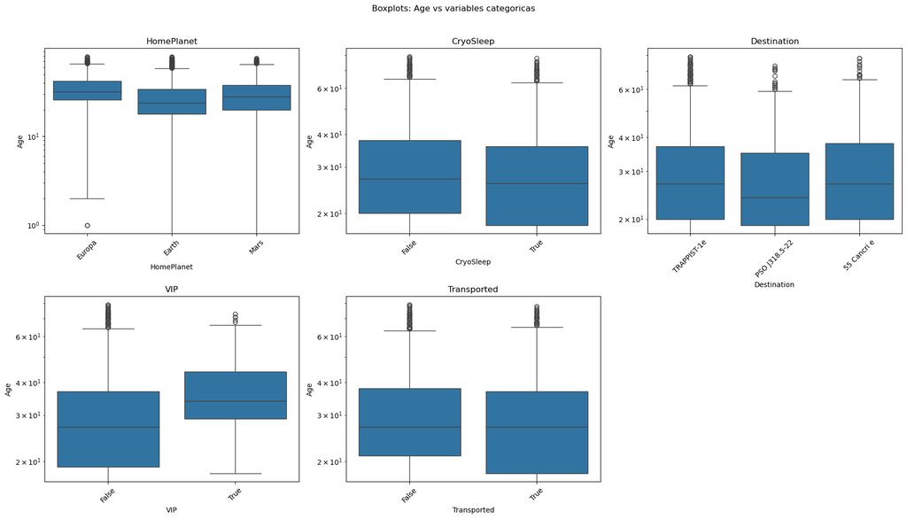

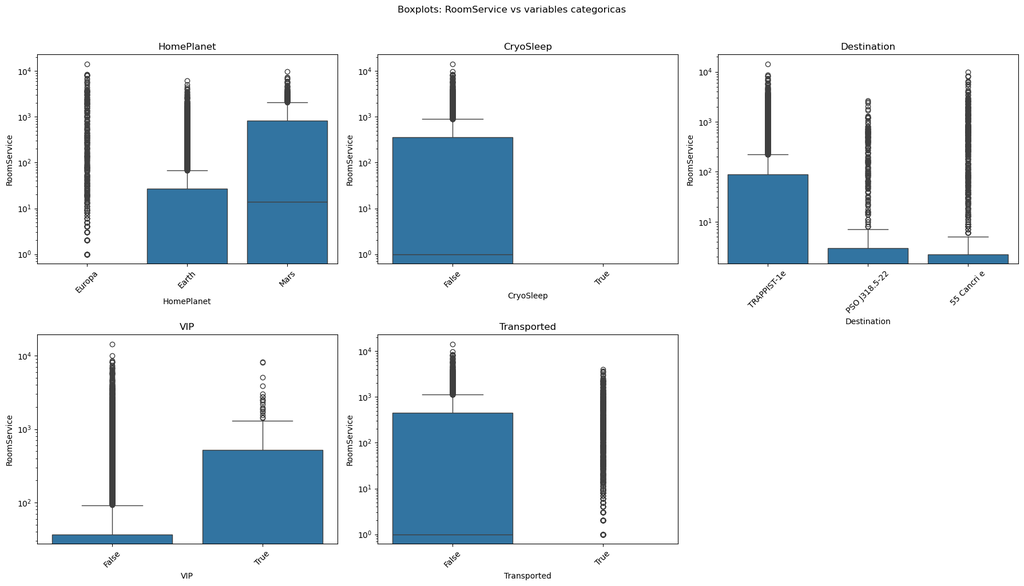

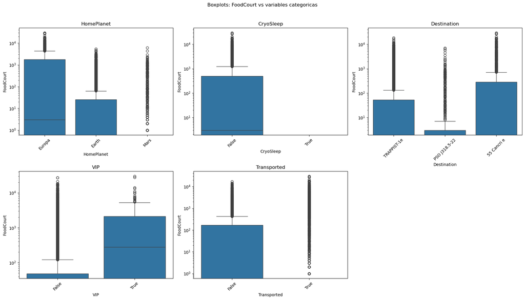

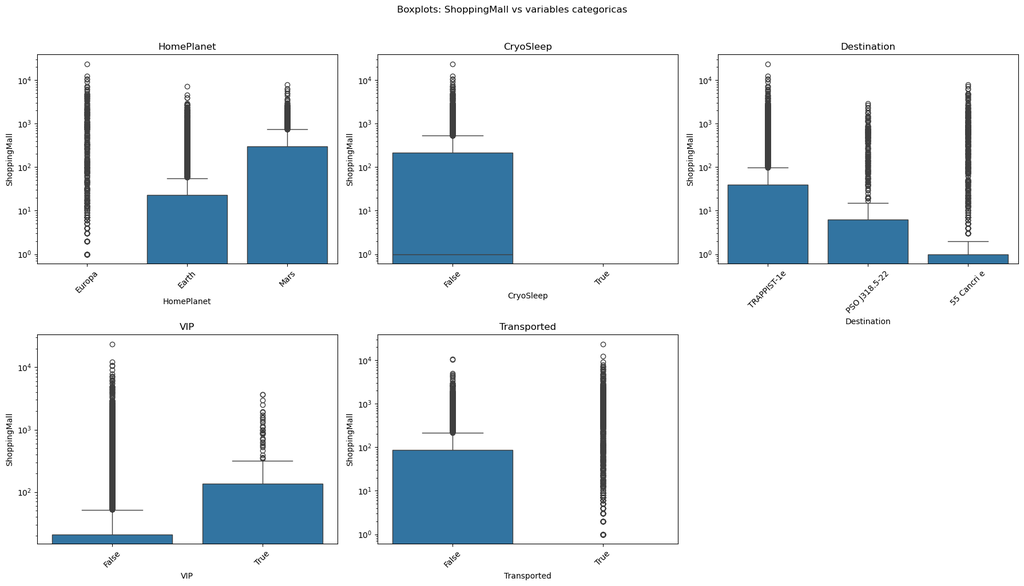

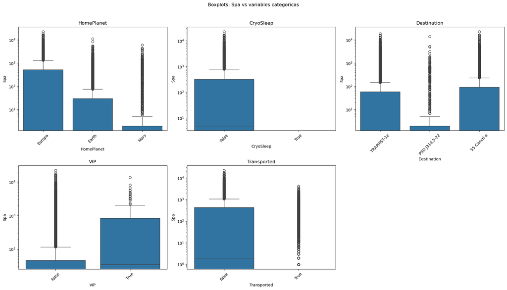

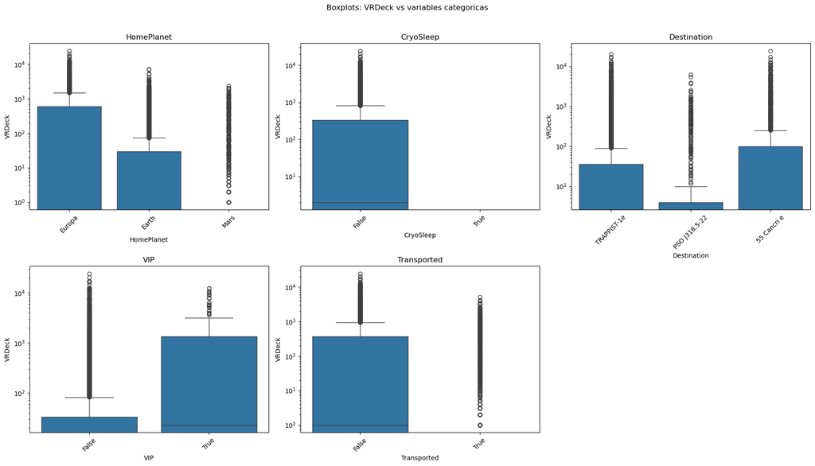

```python
# Numérica vs categórica

#Boxplot

v_cat_analisis_for_plotting = [col for col in v_cat if col not in ['PassengerId', 'Name', 'Cabin']]

n_cat_to_plot = len(v_cat_analisis_for_plotting)
cols_per_fig = 3
rows_per_fig = (n_cat_to_plot + cols_per_fig - 1) // cols_per_fig

for num_col in v_num_cont:
    fig, axes = plt.subplots(rows_per_fig, cols_per_fig, figsize=(6 * cols_per_fig, 5 * rows_per_fig))
    fig.suptitle(f'Boxplots: {num_col} vs variables categoricas', y=1.02)
    axes = axes.flatten()

    for j, cat_col in enumerate(v_cat_analisis_for_plotting):
        ax = axes[j]
        sns.boxplot(x=df[cat_col], y=df[num_col], ax=ax)
        ax.set_title(f'{cat_col}')
        ax.set_xlabel(cat_col)
        ax.set_ylabel(num_col)
        ax.set_yscale('log')
        ax.tick_params(axis='x', rotation=45)

    for k in range(j + 1, len(axes)):
        fig.delaxes(axes[k])

    plt.tight_layout()
    plt.show()
```

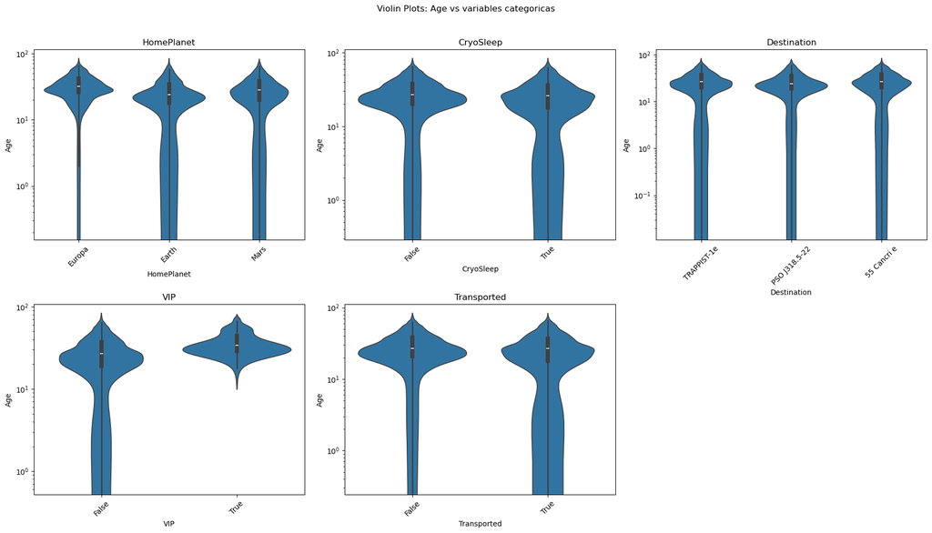

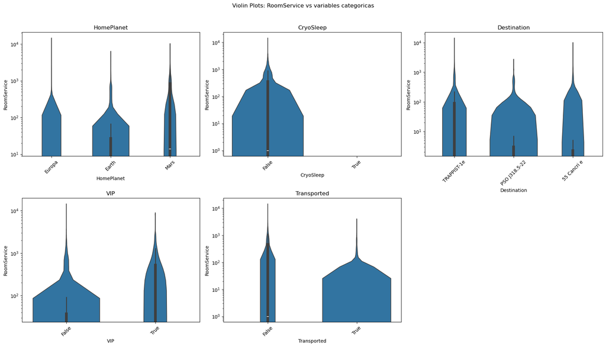

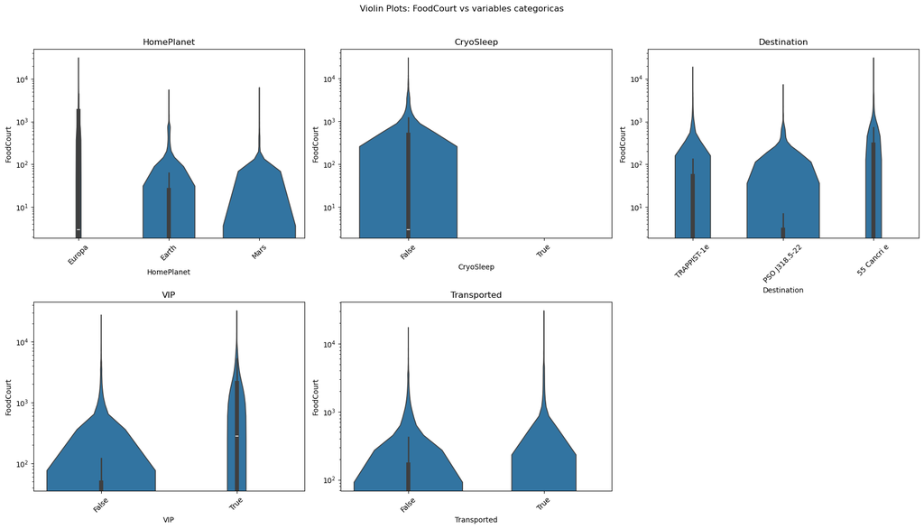

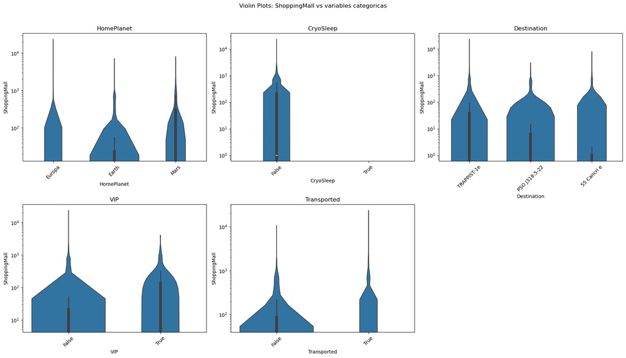

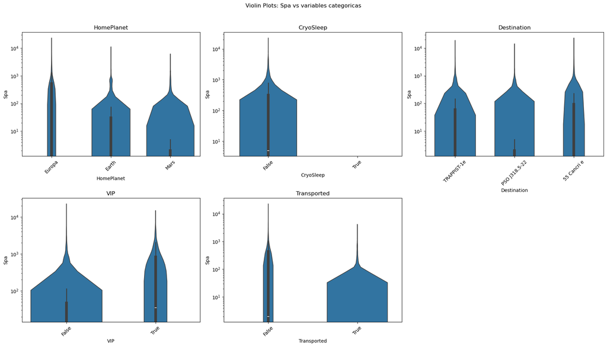

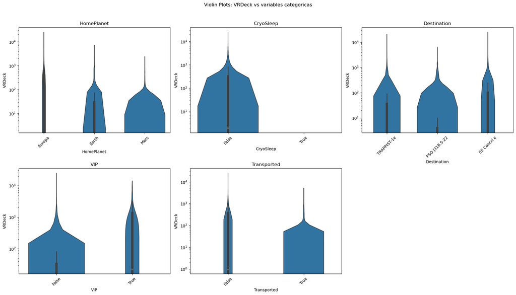

```python
v_cat_analisis_for_plotting = [col for col in v_cat if col not in ['PassengerId', 'Name', 'Cabin']]

n_cat_to_plot = len(v_cat_analisis_for_plotting)
cols_per_fig = 3
rows_per_fig = (n_cat_to_plot + cols_per_fig - 1) // cols_per_fig

for num_col in v_num_cont:
    fig, axes = plt.subplots(rows_per_fig, cols_per_fig, figsize=(6 * cols_per_fig, 5 * rows_per_fig))
    fig.suptitle(f'Violin Plots: {num_col} vs variables categoricas', y=1.02)
    axes = axes.flatten()

    for j, cat_col in enumerate(v_cat_analisis_for_plotting):
        ax = axes[j]
        sns.violinplot(x=df[cat_col], y=df[num_col], ax=ax)
        ax.set_title(f'{cat_col}')
        ax.set_xlabel(cat_col)
        ax.set_ylabel(num_col)
        ax.set_yscale('log')
        ax.tick_params(axis='x', rotation=45) #hay que rotar los labels para que se puedan leer


    for k in range(j + 1, len(axes)):
        fig.delaxes(axes[k])

    plt.tight_layout()
    plt.show()
```

#### Categórica vs categórica

```python
# Tabla de contingencia
for col in v_cat_analisis:
    print("\n",pd.crosstab(df[col], df['Transported']))
```

[output not shown]

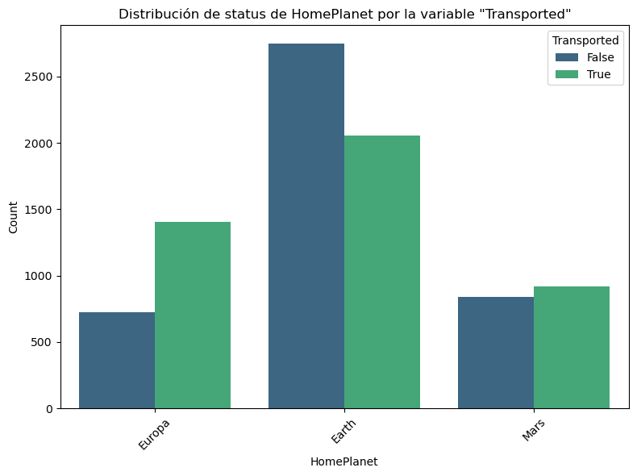

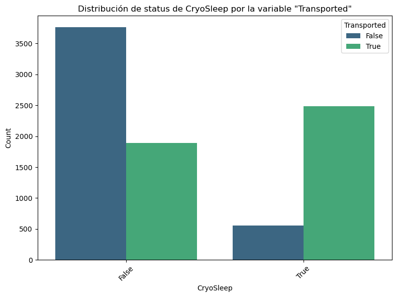

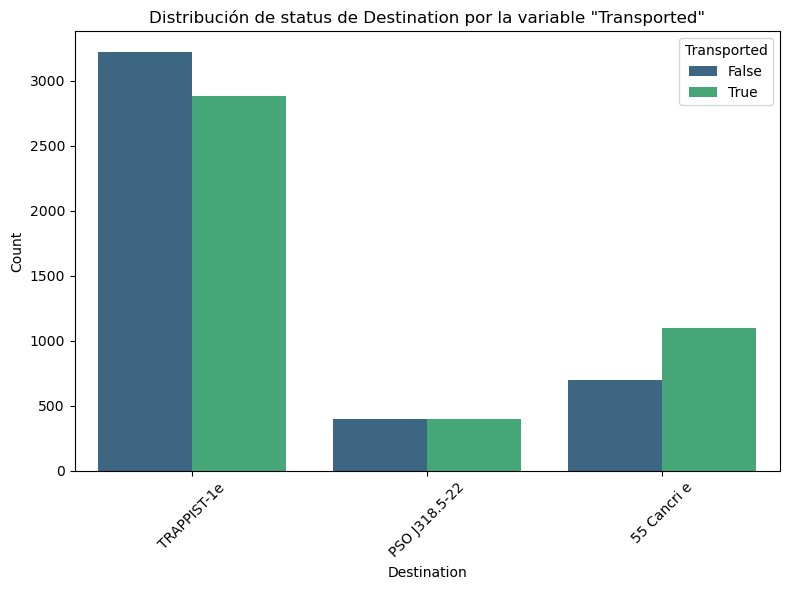

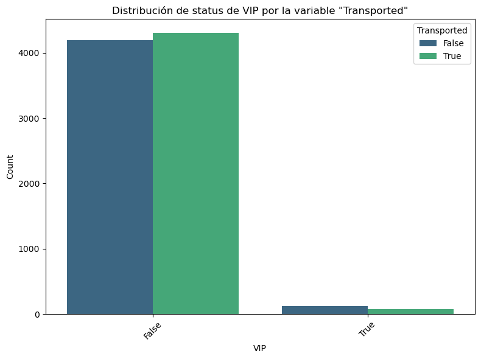

```python
# Barras apiladas

# excluimos cabin, passengerId, y name debido a cardinalidad alta
# y "transported" porque es la variable objetivo.
v_cat_for_barplot = [col for col in v_cat if col not in ['PassengerId', 'Name', 'Cabin', 'Transported']]

num_plots = len(v_cat_for_barplot)

if num_plots > 0:
    for cat_col in v_cat_for_barplot:
        fig, ax = plt.subplots(1, 1, figsize=(8, 6))
        sns.countplot(x=df[cat_col], hue=df['Transported'], ax=ax, palette='viridis')
        ax.set_title(f'Distribución de status de {cat_col} por la variable "Transported"')
        ax.set_xlabel(cat_col)
        ax.set_ylabel('Count')
        ax.legend(title='Transported', loc='upper right')
        ax.tick_params(axis='x', rotation=45)
        plt.tight_layout()
        plt.show()
else:
    print("No se encontraron variables categóricas adecuadas para gráficos de barras frente a 'Transported'.")
```

Para analizar 'Cabin' de manera significativa, extraeremos sus componentes: Deck, CabinNum, y Side.

```python
# Extraer Deck, CabinNum y Side de la columna 'Cabin'
df[['Deck', 'CabinNum', 'Side']] = df['Cabin'].str.split('/', expand=True)

# Convertir 'CabinNum' a numérico si es posible
df['CabinNum'] = pd.to_numeric(df['CabinNum'], errors='coerce')

# Mostrar los primeros registros con las nuevas columnas
display(df[['Cabin', 'Deck', 'CabinNum', 'Side', 'Transported']].head())
```

|  | Cabin | Deck | CabinNum | Side | Transported |
| --- | --- | --- | --- | --- | --- |
| 0 | B/0/P | B | 0 | P | False |
| 1 | F/0/S | F | 0 | S | True |
| 2 | A/0/S | A | 0 | S | False |
| 3 | A/0/S | A | 0 | S | False |
| 4 | F/1/S | F | 1 | S | True |

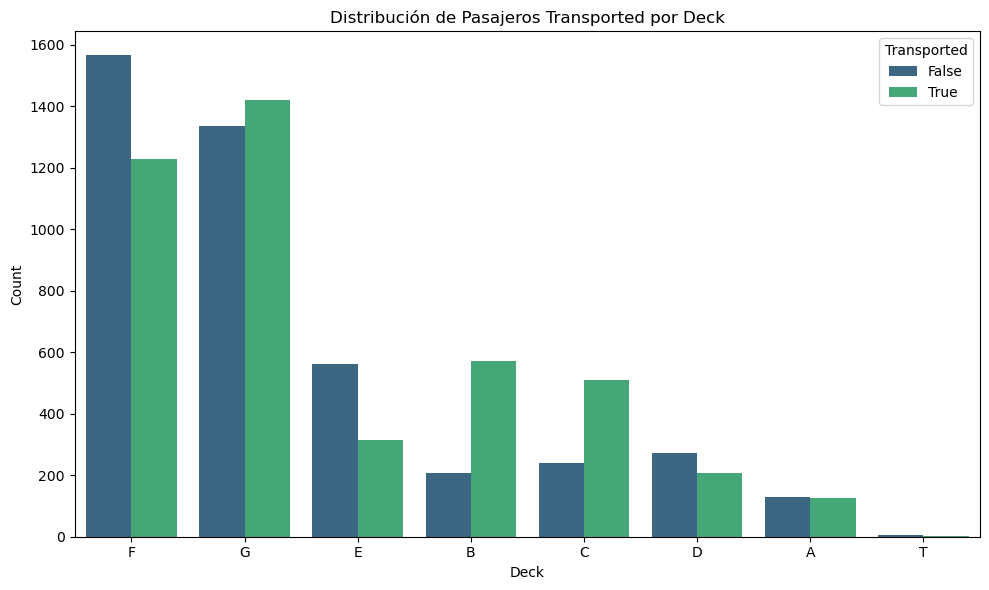

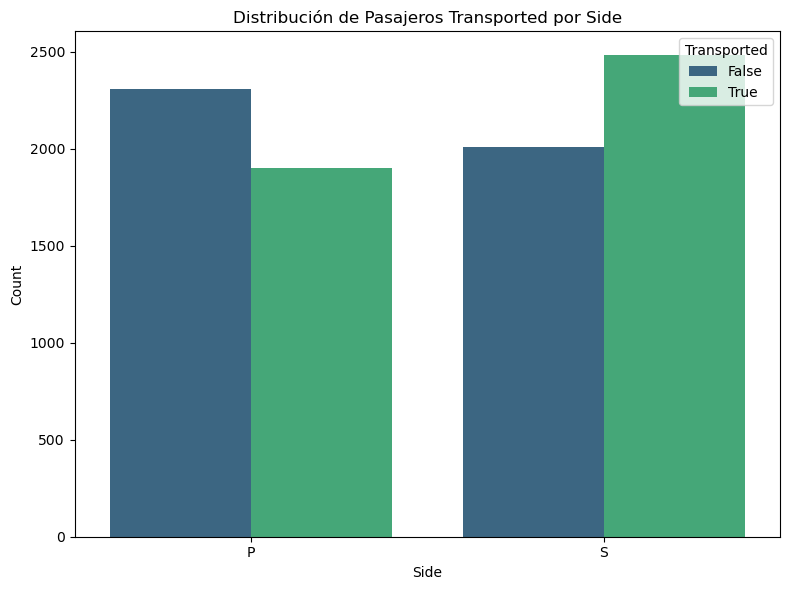

```python
# Gráficos de barras para 'Deck' vs 'Transported'
fig, ax = plt.subplots(figsize=(10, 6))
sns.countplot(data=df, x='Deck', hue='Transported', ax=ax, palette='viridis', order=df['Deck'].value_counts().index)
ax.set_title('Distribución de Pasajeros Transported por Deck')
ax.set_xlabel('Deck')
ax.set_ylabel('Count')
ax.legend(title='Transported', loc='upper right')
plt.tight_layout()
plt.show()

# Gráficos de barras para 'Side' vs 'Transported'
fig, ax = plt.subplots(figsize=(8, 6))
sns.countplot(data=df, x='Side', hue='Transported', ax=ax, palette='viridis')
ax.set_title('Distribución de Pasajeros Transported por Side')
ax.set_xlabel('Side')
ax.set_ylabel('Count')
ax.legend(title='Transported', loc='upper right')
plt.tight_layout()
plt.show()
```

## 6. Correlaciones y multicolinealidad

- Usa `df.corr()` para medir relaciones lineales.
- Visualiza con mapas de calor (heatmap).
- Si dos variables están muy correlacionadas (> 0.9), considera eliminar una para evitar redundancia.

#### Correlaciones

```python
# Correlaciones

matriz_corr = df[v_num_cont].corr(numeric_only=True)
print(matriz_corr)
```

```
                   Age  RoomService  FoodCourt  ShoppingMall       Spa  \
Age           1.000000     0.068629   0.127390      0.033148  0.120946
RoomService   0.068629     1.000000  -0.015126      0.052337  0.009244
FoodCourt     0.127390    -0.015126   1.000000     -0.013717  0.221468
ShoppingMall  0.033148     0.052337  -0.013717      1.000000  0.014542
Spa           0.120946     0.009244   0.221468      0.014542  1.000000
VRDeck        0.099590    -0.018624   0.224572     -0.007849  0.147658

                VRDeck
Age           0.099590
RoomService  -0.018624
FoodCourt     0.224572
ShoppingMall -0.007849
Spa           0.147658
VRDeck        1.000000
```

#### Mapa de calor

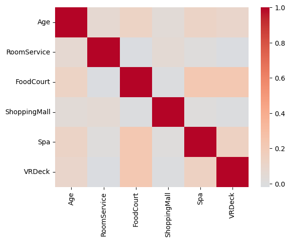

```python
# Mapa de calor
sns.heatmap(matriz_corr, annot=False, cmap='coolwarm', center=0)
plt.show()
```

## 7. Detección de patrones y relaciones no lineales

- Explora posibles **interacciones** entre variables.
- Usa gráficos de dispersión por categorías, *pairplots*, *jointplots*.
- Identifica relaciones no lineales o dependencias complejas.

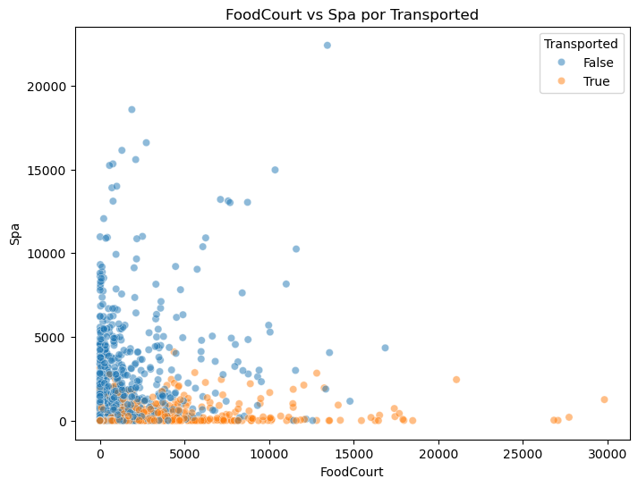

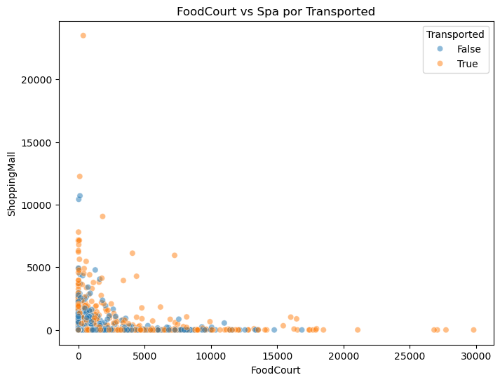

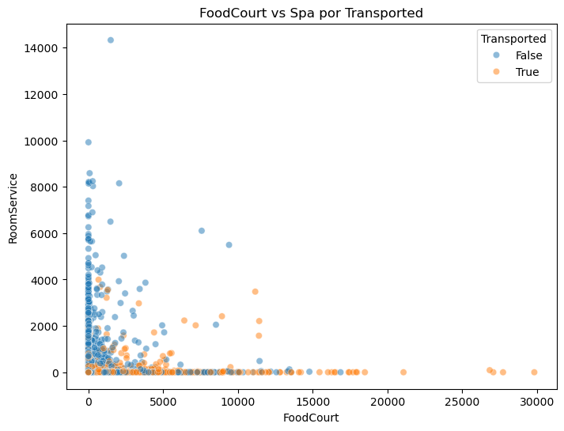

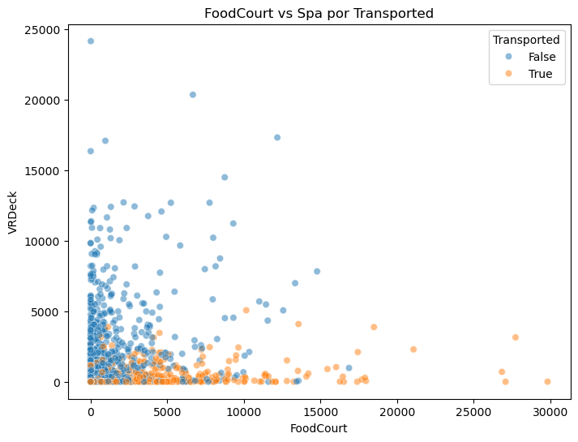

```python
# Interacciones entre variables

# Pairplots
plt.figure(figsize=(8, 6))
sns.scatterplot(data=df, x='FoodCourt', y='Spa', hue='Transported', alpha=0.5)
plt.title('FoodCourt vs Spa por Transported')
plt.show()

plt.figure(figsize=(8, 6))
sns.scatterplot(data=df, x='FoodCourt', y='ShoppingMall', hue='Transported', alpha=0.5)
plt.title('FoodCourt vs Spa por Transported')
plt.show()

plt.figure(figsize=(8, 6))
sns.scatterplot(data=df, x='FoodCourt', y='RoomService', hue='Transported', alpha=0.5)
plt.title('FoodCourt vs Spa por Transported')
plt.show()


plt.figure(figsize=(8, 6))
sns.scatterplot(data=df, x='FoodCourt', y='VRDeck', hue='Transported', alpha=0.5)
plt.title('FoodCourt vs Spa por Transported')
plt.show()
v_num_cont = ['Age', 'RoomService', 'FoodCourt', 'ShoppingMall', 'Spa', 'VRDeck']


v_cat = ['PassengerId', 'HomePlanet', 'CryoSleep', 'Cabin', 'Destination', 'VIP', 'Name', 'Transported']
```

## 8 Exportación de los datos limpios

Exporta tus datos resultantes del EDA a un archivo csv llamándolo <nombre del archivo original>_clean.csv

```python
# Datos limpios
df.to_csv('clean.csv', index=False)
```

## 9. Comentarios y conclusiones (escribe aquí)

# Escribe tus comentarios aquí

#### ¿Qué patrones encontraste?

```python
cryosleep_transported = df[df['CryoSleep'] == True]['Transported'].value_counts(normalize=True) * 100
print("Porcentaje de pasajeros en CryoSleep que fueron Transportados:")
print(cryosleep_transported)
```

```
Porcentaje de pasajeros en CryoSleep que fueron Transportados:
Transported
True     81.758314
False    18.241686
Name: proportion, dtype: float64
```

- El patrón más claro es que CryoSleep predice muy bien si alguien fue transportado. Si el pasajero está dormido (CryoSleep=True), no puede gastar en los servicios de la nave, por eso su gasto es $0 en todo. Y resulta que estar dormido también se relaciona con ser transportado: 81.8% de los que estaban en CryoSleep fueron transportados, contra solo 33.5% de los que no lo estaban.
- Además, el planeta de origen (HomePlanet) también influye un poco: los de Europa tienen más probabilidad de ser transportados (65.9%) que los de la Tierra (42.8%). En cambio, las variables de gasto están muy correlacionadas entre sí de forma débil (nada pasa 0.22), así que no hay dos variables que digan lo mismo.

#### ¿Qué problemas detectaste?

- Había datos faltantes en casi todas las columnas, que se rellenaron con mediana en las numéricas y moda en las categóricas. No había filas duplicadas.
- También hay muchos "outliers" en las variables de gasto, pero no son errores: la mayoría de la gente gasta $0 y unos pocos gastan mucho, así que esos "outliers" son comportamiento real, no basura en los datos. Por eso no se eliminaron.

#### ¿Qué transformaciones aplicarás antes del modelado?

- Codificar HomePlanet, CryoSleep, Destination y VIP con One-Hot Encoding.
- Dado que CryoSleep predice casi perfectamente el gasto (=0), evaluar si conviene usar CryoSleep como variable fuerte de entrada o si hay riesgo de fuga de información al combinarla con las variables de gasto.

##### ¿Cuáles son las variables que **conservarás** y cuáles **desecharás**?

- Las variables que se desecharán son aquellas que poseen cardinalidad:
  - PassengerId (solo identificador).
  - Name (sin valor predictivo).
  - Cabin en su forma original (se reemplaza por sus componentes).